# CitiBike Dataset Exploration

## By Hunter Bravence

## Introduction

**This data set is about public bike sharing information** **The data spands over one year for 2019 and it's from New York City** **This is open for the too the public and the release new data ever month**

### What is the structure of your dataset?

> The structure of the dataset is made out of severaly smaller datasets that you have to peice together

### What are the main features of interest in the data set

> the main features of the data set are trip duration, lat and long, gender, birth year, usertype. start and stop station id/name, bike id, and start and stop time.

### What features in the dataset do you will help support your investigation into your features of intereset?

> Start time, lat and long, trip duration, user type, birth year, and gender. Can all provide pretty solid insight into the demographics

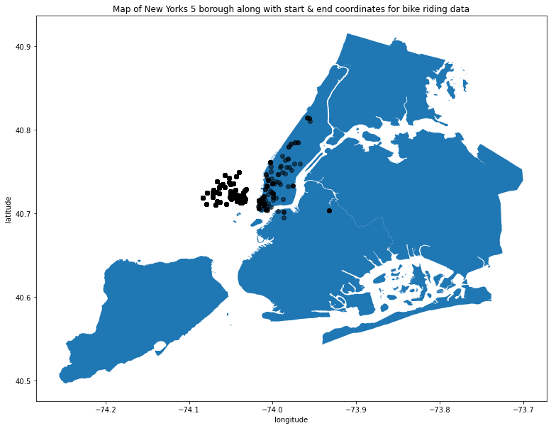

```python
#plotting the starting and ending coordinate on a map of new york
fig, ax = plt.subplots(1, figsize = (20,10))
base= New_York.plot(ax=ax)
ny_19.plot(ax = base, alpha = .5, color = 'black')
plt.title('Map of New Yorks 5 borough along with start & end coordinates for bike riding data')
plt.ylabel('latitude')
plt.xlabel('longitude')
plt.savefig('map of new york for bike ride data');
```

> Not a lot of females are subscribers, the question from should you double down on marketing to men since they seem to be the ones who really use the service or should you target women since they are not using the services as much. Why aren't their that many female subscribers.

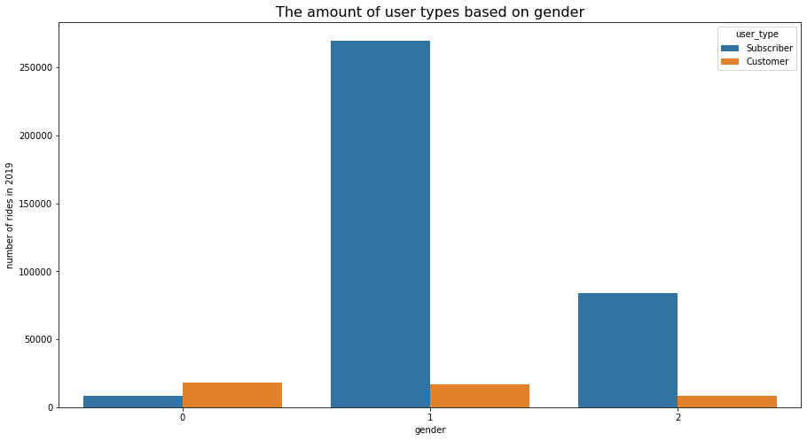

```python
plt.figure(figsize = (15,8))
sb.countplot(data = ny_19, x= 'gender', hue = 'user_type')
plt.title('The amount of user types based on gender' , fontsize = 16)
plt.ylabel('number of rides in 2019')
plt.savefig('Gender chart')
```

> I think the customer type would much more likely be tourist visiting new york, because have the count stays much more consitent through out the work day, unlike the subscriber were it seem's to peak at the start and at the end of the work day.

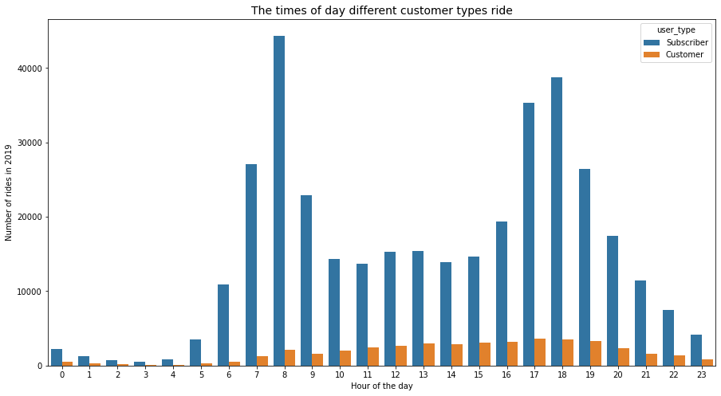

```python
plt.figure(figsize= (15,8))
sb.countplot(data = ny_19, x = 'start_hour', hue  = 'user_type')
plt.xlabel('Hour of the day')
plt.ylabel('Number of rides in 2019')
plt.title('The times of day different customer types ride', fontsize = 14)
plt.savefig('hours of the chart')
```

> it almost seems with log transformation with trip duration that the relationship could be a linear. This shows that one time users are more likely to have longer trip but still go about same distance as the subscribers. This also shows that further distance that you travel the longer your trip will be. Although distance doesn't seem to be what cause some trips to be longer than others

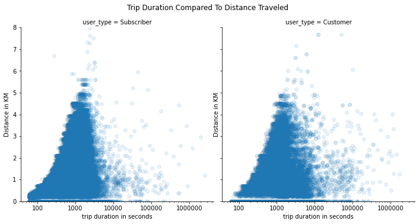

```python
tick_locs = [100, 1000, 10000, 100000, 1000000]
g = sb.FacetGrid(data = ny_19, col = 'user_type', height = 5)
g.map(plt.scatter, 'trip_duration', 'distance' , alpha = .1)
g.set(xscale = 'log')
g.set(xticks = tick_locs, xticklabels = tick_locs)
g.set(xlabel = 'trip duration in seconds', ylabel = 'Distance in KM')
g.set(ylim = (0, 8))
g.fig.suptitle('Trip duration compared to distance traveled'.title(),  y= 1.04)
plt.savefig('trip durations VS distance');
```

> For the distance it doesn't really seem to matter what the gender is or if the gender is know, although the male gender subscriber seems like it has the most outliers. The really difference in distance traveled seems to be user type, where it seems a one time user on average travels further.

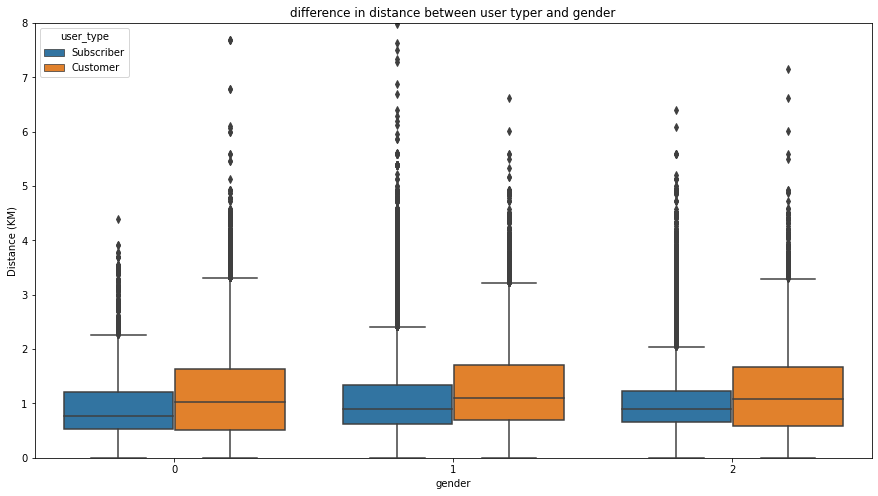

```python
plt.figure(figsize = [15, 8])
sb.boxplot(data = ny_19, x = 'gender', y = 'distance', hue = 'user_type')
plt.ylim(0,8)
plt.title('difference in distance between user typer and gender')
plt.ylabel('Distance (KM)')
plt.savefig('gender and usertype')
```

```python
!jupyter nbconvert Slide_show.ipynb --to slides --post serve --template output_toggle
```